# Zadání zápočtové úlohy

2024-06-20

## Instrukce

Zpracujte data o pohybové aktivitě z chytrých náramků.

- Dle zadání zreprodukujte tabulky a grafy.
- Vypracujte Quarto report (nebo R Notebook) zobrazující nejen grafy a tabulky, ale také textový popis řešení.
- **Výsledný dokument ve formátu html nahrajte spolu se zdrojovými kódy (jednak R a jednak qmd včetně složek v případě Quarto reportu, nebo rmd v případě R Notebooku) na stránky předmětu v systému** [Moodle](https://moodle.prf.ujep.cz/mod/assign/view.php?id=11344) **(neváhejte nahrát celou pracovní složku včetně zdrojových dat).**

V této zápočtové úloze budete zpracovávat následující datové soubory:

- `Gadgetbridge`
- `schedule.csv`

Jako nápověda může posloužit soubor `README.docx`.

Ze souboru `Gadgetbridge` načtěte klíčovou datovou tabulku.

```r
library(DBI)
con <- dbConnect(RSQLite::SQLite(), dbname="Gadgetbridge")
df <- dbGetQuery(con,'select * from MI_BAND_ACTIVITY_SAMPLE')
dbDisconnect(con)
```

kde si knihovnu `DBI` pravděpodobně budete muset doinstalovat.

K řešení se doporučuje využití těchto knihoven:

```r
library(dplyr)
library(ggplot2)
library(tidyr)
library(lubridate)
```

Poslední uvedená knihovna se Vám pak může hodin například pro převedení proměnné `TIMESTAMP` na datum a čas. Nicméně jistě existuje i jiné řešení pro tuto dílčí úlohu.

```r
df$datetime <- as_datetime(df$TIMESTAMP)
```

Z času odečtěte 2 hodiny.

Vytvořte následující graf. Uživatel je určen proměnnou `DEVICE_ID`. V grafu je použita sekundární osa (`sec.axis`).

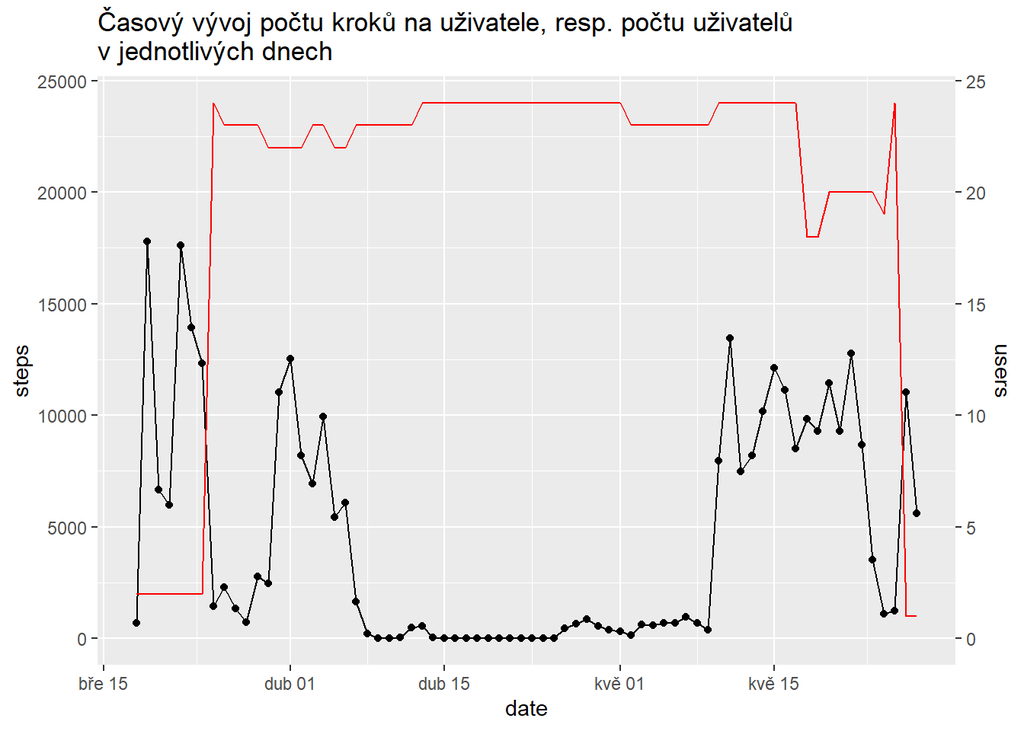

Vytvořte následující tabulku. Tabulka zobrazuje ve vybraných dnech počty kroků jednotlivých uživatelů. K zobrazení je využita funkce `knitr::kable()`.

| date | 1 | 2 | 3 | 4 | 5 | 6 | 7 | 8 | 9 | 10 | 11 | 12 | 14 | 15 | 16 | 17 | 18 | 19 | 20 | 21 | 22 | 23 | 24 | 26 |
| --- | --- | --- | --- | --- | --- | --- | --- | --- | --- | --- | --- | --- | --- | --- | --- | --- | --- | --- | --- | --- | --- | --- | --- | --- |
| 2021-05-10 | 13180 | 604 | 9052 | 8085 | 10133 | 2158 | 11152 | 6871 | 9591 | 1249 | 6663 | 4099 | 14154 | 599 | 11136 | 15576 | 9865 | 9179 | 16535 | 0 | 7368 | 12285 | 9171 | 2066 |
| 2021-05-11 | 0 | 2581 | 15192 | 13412 | 14645 | 10874 | 15276 | 8578 | 19689 | 10369 | 3488 | 12238 | 20935 | 12562 | 17723 | 20041 | 12596 | 12716 | 22344 | 11777 | 16961 | 17432 | 15804 | 15248 |
| 2021-05-12 | 0 | 3571 | 7334 | 9368 | 9700 | 9312 | 792 | 10433 | 10696 | 7470 | 13254 | 6155 | 10558 | 4996 | 7757 | 12048 | 4109 | 5888 | 10830 | 7591 | 5166 | 10031 | 9482 | 3247 |
| 2021-05-13 | 0 | 6708 | 9427 | 7471 | 12519 | 8887 | 5730 | 11650 | 15756 | 5546 | 8367 | 10255 | 14287 | 12362 | 6188 | 6100 | 5166 | 6763 | 10154 | 5461 | 10636 | 6709 | 8977 | 1534 |
| 2021-05-14 | 0 | 4567 | 13589 | 15245 | 13009 | 2567 | 1355 | 7226 | 10917 | 18109 | 10416 | 8769 | 16956 | 11204 | 9076 | 11467 | 7180 | 11408 | 12587 | 9880 | 14032 | 10597 | 18215 | 5556 |
| 2021-05-15 | 0 | 10757 | 7159 | 25416 | 14593 | 5477 | 6880 | 4462 | 14084 | 26957 | 7640 | 16720 | 23519 | 11378 | 5512 | 7088 | 9536 | 13501 | 24024 | 2702 | 20009 | 7491 | 17225 | 8926 |
| 2021-05-16 | 0 | 5889 | 9068 | 17179 | 21280 | 10391 | 9468 | 10818 | 14088 | 19439 | 8119 | 12867 | 13707 | 10814 | 10877 | 11452 | 7658 | 4444 | 10175 | 2368 | 18801 | 16421 | 12668 | 9536 |
| 2021-05-17 | 0 | 5398 | 5257 | 7098 | 10820 | 6242 | 9362 | 11772 | 7137 | 8397 | 5194 | 9155 | 13552 | 1242 | 5305 | 11541 | 7526 | 10130 | 14924 | 12890 | 7729 | 8966 | 11107 | 13394 |
| 2021-05-18 | 770 | 7480 | NA | 15847 | 13177 | 13685 | 0 | NA | 8953 | 15699 | 11691 | 3919 | 14397 | 5561 | 4601 | 11456 | NA | 9021 | NA | 14191 | 13650 | NA | NA | 12982 |
| 2021-05-19 | 16013 | 6174 | NA | 9928 | 7876 | 10064 | 0 | NA | 6508 | 11199 | 12504 | 11805 | 12169 | 1503 | 9779 | 16186 | NA | 7301 | NA | 12881 | 12939 | NA | NA | 2469 |
| 2021-05-20 | 11210 | 7156 | NA | 14635 | 15043 | 4631 | 13241 | 12398 | 11410 | 14015 | 9541 | 8885 | 16573 | 8714 | 10124 | 7916 | NA | 9074 | NA | 12187 | 16369 | NA | 15918 | 9836 |
| 2021-05-21 | 12816 | 6151 | NA | 8776 | 12159 | 5589 | 0 | 20490 | 3283 | 9038 | 624 | 12946 | 3311 | 6740 | 15496 | 9709 | NA | 8319 | NA | 18482 | 7534 | NA | 15743 | 8790 |
| 2021-05-22 | 14205 | 3672 | NA | 11541 | 17436 | 8507 | 23934 | 22327 | 14632 | 15388 | 17539 | 6429 | 0 | 6429 | 10714 | 7504 | NA | 7315 | NA | 15379 | 7028 | NA | 20599 | 24581 |
| 2021-05-23 | 7095 | 7250 | NA | 5472 | 15546 | 5140 | 7739 | 5589 | 11176 | 6360 | 4996 | 15269 | 0 | 15320 | 19609 | 6944 | NA | 4393 | NA | 2697 | 11452 | NA | 12393 | 8846 |

V poslední části již využijete také data v souboru `schedule.csv`, který obsahuje školní rozvrh uživatelů.

| day | subject | from | to | school |
| --- | --- | --- | --- | --- |
| Monday | Czech | 8:00 | 8:45 | TRUE |
| Monday | Math | 8:55 | 9:40 | TRUE |
| Monday | Natural Science | 9:50 | 10:35 | TRUE |
| Monday | Czech | 11:00 | 11:45 | TRUE |
| Tuesday | Czech | 8:00 | 8:45 | TRUE |
| Tuesday | Math | 8:55 | 9:40 | TRUE |
| Tuesday | Physical Education | 9:50 | 10:35 | TRUE |
| Tuesday | English | 11:00 | 11:45 | TRUE |
| Tuesday | Czech | 11:55 | 12:40 | TRUE |
| Wednesday | Czech | 8:00 | 8:45 | TRUE |
| Wednesday | Math | 8:55 | 9:40 | TRUE |
| Wednesday | Art | 9:50 | 10:35 | TRUE |
| Wednesday | Work Activities | 11:00 | 11:45 | TRUE |
| Thursday | Czech | 8:00 | 8:45 | TRUE |
| Thursday | Math | 8:55 | 9:40 | TRUE |
| Thursday | Czech | 9:50 | 10:35 | TRUE |
| Thursday | Physical Education | 11:00 | 11:45 | TRUE |
| Thursday | Natural Science | 11:55 | 12:40 | TRUE |
| Friday | Czech | 8:00 | 8:45 | TRUE |
| Friday | Math | 8:55 | 9:40 | TRUE |
| Friday | Czech | 9:50 | 10:35 | TRUE |
| Friday | Music | 11:00 | 11:45 | TRUE |

Vaším úkolem je zobrazit následující graf, který zpracovává

- data z proměnné `HEART_RATE` původní databáze,
- přičemž započítává pouze ta pozorování, ve kterých tato proměnná nabývá hodnot $(0,255)$,
- ve dnech dle první zobrazované tabulky, tj. od 10. května do 23. května,
- v době výuky dle výše uvedeného rozvrhu, konkrétně v závislosti na vyučovaných předmětech.

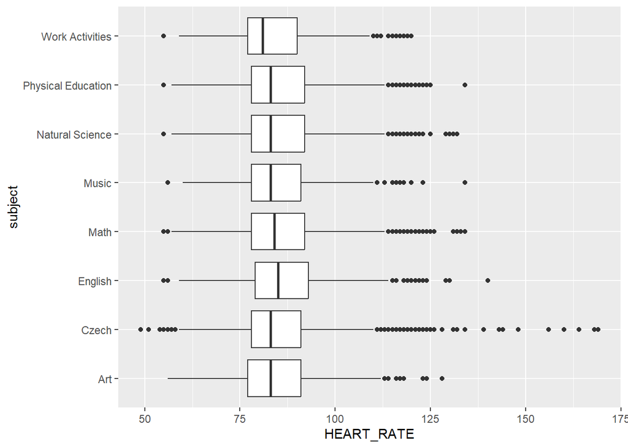